# **Econometric Models in Practice**

### 9.9.5 Nonstasioner & Alternatif: Toda–Yamamoto (TY) dan VECM

- **Jika variabel I(1) tidak terkointegrasi**: gunakan **Toda–Yamamoto**. Caranya: estimasi VAR pada **level data** dengan orde $p + d_{\max}$ (di mana $d_{\max}$ adalah orde integrasi maksimum variabel), lalu **uji hanya koefisien pada $p$ lag pertama** dengan Wald. Ini menjaga validitas asimtotik uji meskipun ada akar unit.

```r
# Sketsa TY pada data simulasi (anggap dmax = 1)
p     <- p2
dmax  <- 1
m_TY  <- VAR(dat, p = p + dmax, type = "const")

# Uji x -> y hanya pada lag 1..p (bukan lag tambahan dmax)
eq_y_TY <- m_TY$varresult$y
coef_names_TY <- names(coef(eq_y_TY))
restr_TY <- grep("^x\\.l([1-9]|1[0-9])$", coef_names_TY, value = TRUE)  # semua lag x
# Pilih hanya lag 1..p (bukan lag p+1..p+dmax)
lag_numbers <- as.integer(sub("x\\.l", "", restr_TY))
restr_TY <- restr_TY[lag_numbers <= p]

linearHypothesis(eq_y_TY, restr_TY)
```

```
##
## Linear hypothesis test:
## x.l1 = 0
##
## Model 1: restricted model
## Model 2: y ~ -1 + (y.l1 + x.l1 + y.l2 + x.l2 + const)
##
##   Res.Df    RSS Df Sum of Sq      F    Pr(>F)
## 1    394 455.04
## 2    393 390.06  1    64.975 65.464 7.455e-15 ***
## ---
## Signif. codes:  0 '***' 0.001 '**' 0.01 '*' 0.05 '.' 0.1 ' ' 1
```

- **Jika terkointegrasi** (I(1) & memiliki hubungan jangka panjang): gunakan **VECM** dan uji eksogenitas lemah: apakah lag differensi $x$ dan/atau komponen error-correction $ECM$ berpengaruh pada persamaan $y$.

**Praktik Terbaik & Peringatan**

1. **Pilih lag yang memadai** (AIC/BIC/HQ) dan cek **serial correlation** residual. Autokorelasi sisa dapat memalsukan hasil uji.
2. **Stasioneritas & kointegrasi**: identifikasi apakah perlu differencing/VECM/TY.
3. **Kondisi sampel**: pada sampel kecil, gunakan **bootstrap** untuk robust p-values.
4. **Interpretasi hasil**: “Granger causes” berarti **menambah informasi prediktif**, bukan bukti kausalitas struktural.
5. **Stabilitas**: cek `roots(m)`; jika ada akar $\ge 1$, perbaiki spesifikasi terlebih dahulu.
6. **Multivariat**: dalam sistem >2 variabel, uji blok eksogenitas untuk sekelompok variabel sekaligus (set `cause = c("x1","x2")`).

**Contoh Ringkas Visualisasi (Opsional)**

```r
# Jika uji x -> y signifikan, Anda dapat mengilustrasikan transmisi shock via IRF
irf_obj <- irf(m2, impulse = "x", response = "y", n.ahead = 20, boot = TRUE, ortho = FALSE)
plot(irf_obj)
```

[output not shown]

**Ringkasan**

- Granger causality menguji apakah lag $x$ **menambah kemampuan prediksi** $y$ di luar lag $y$ sendiri.
- Di-implementasi sebagai **uji Wald** pada blok koefisien lag $x$ di persamaan $y$ dalam sistem VAR.
- **vars::causality()** memudahkan uji blok; bisa juga manual via `linearHypothesis()`.
- Perhatikan **stasioneritas**, **kointegrasi**, dan gunakan **Toda–Yamamoto** atau **VECM** bila diperlukan.

## 9.10 IRF & FEVD

- **IRF**: respons dinamis variabel terhadap **kejutan satu-satuan** pada salah satu inovasi. Karena inovasi saling berkorelasi, perlu **ortogonalization** (umum: **Cholesky** — urutan variabel penting!).
- **FEVD**: proporsi varians kesalahan ramalan pada horizon tertentu yang dijelaskan oleh setiap inovasi.
- **IRF (Impulse Response Function)**: respons dinamis variabel terhadap **kejutan satu-satuan** pada salah satu inovasi. Karena inovasi (residual) antar persamaan umumnya **berkorelasi**, perlu **ortogonalization** agar shock menjadi bebas. Metode umum: **Cholesky**, sehingga **urutan variabel (ordering)** berpengaruh pada hasil IRF.
- **FEVD (Forecast Error Variance Decomposition)**: proporsi varians **kesalahan ramalan** pada horizon tertentu yang dijelaskan oleh **setiap inovasi** (shock). Memberi gambaran siapa “penggerak” utama variabilitas ramalan suatu variabel.

**Teori Singkat**

Misal sistem VAR($p$) stabil:
$$Y_t = c + A_1 Y_{t-1} + \cdots + A_p Y_{t-p} + u_t,\qquad E(u_t)=0,\;
E(u_t u_t^\top)=\Sigma_u.$$

Representasi MA($\infty$) (jika stabil):
$$Y_t = \mu + \sum_{h=0}^\infty \Phi_h\,u_{t-h},\quad \Phi_0=I_K,\quad
\Phi_h = A_1\Phi_{h-1} + \cdots + A_p\Phi_{h-p}.$$

### 9.10.1 IRF Ortogonal (Cholesky)

Ambil $P$ sehingga $\Sigma_u = P P^\top$ (Cholesky). Shock ortogonal: $\tilde u_t = P^{-1} u_t$.
IRF pada horizon $h$:
$$\Psi_h = \Phi_h P.$$
Entri $(i,j)$ dari $\Psi_h$ adalah respons variabel $i$ pada horizon $h$ terhadap **shock ortogonal** pada variabel $j$ sebesar satu standar deviasi. > Sensitif terhadap **ordering** variabel.

### 9.10.2 IRF Tergeneralisasi (GIRF)

Tidak perlu ortogonalization; **invarian** terhadap ordering (Pesaran & Shin, 1998). Untuk shock pada variabel $j$:
$$\text{GIRF}_j(h) \;=\;
\frac{\Phi_h\,\Sigma_u\,e_j}{\sqrt{\Sigma_{u,jj}}},$$
dengan $e_j$ vektor basis dan $\Sigma_{u,jj}$ elemen diagonal ke-$j$.

### 9.10.3 FEVD

Varians kesalahan ramalan $h$-langkah untuk variabel $i$ dikurasi oleh kontribusi tiap shock $j$:
$$\mathrm{FEVD}_{i\leftarrow j}(H) \;=\;
\frac{\sum_{h=0}^{H-1} \left( e_i^\top \Psi_h e_j
\right)^2}{\sum_{h=0}^{H-1} \left( e_i^\top \Psi_h \Psi_h^\top e_i
\right)} \quad
\text{(ortogonal / Cholesky)}.$$
Untuk GIRF, gantikan $\Psi_h$ dengan bentuk ter-generalisasi.

**Implementasi R — Kode Aman (dengan Fallback)**

```r
suppressPackageStartupMessages({
  library(vars)
  library(ggplot2)
  library(dplyr)
  library(tidyr)
  library(purrr)
})
```

### 9.10.4 Simulasi VAR(1) Stabil (disarankan untuk kelas)

```r
set.seed(123)
K <- 2; Tn <- 300
A <- matrix(c(0.5, 0.2,
              0.1, 0.6), K, K)   # stabil (akar eigen < 1)
Eps <- matrix(rnorm(K*Tn), ncol = K)
Y   <- matrix(0, nrow = Tn, ncol = K)
for (t in 2:Tn) Y[t,] <- A %*% Y[t-1,] + Eps[t,]
dat <- data.frame(y1 = Y[,1], y2 = Y[,2])

m <- VAR(dat, p = 1, type = "const")
roots(m)           # cek stabilitas (semua < 1)
```

```
## [1] 0.5688521 0.3895353
```

### 9.10.5 IRF dengan Fallback (Cholesky → GIRF bila perlu)

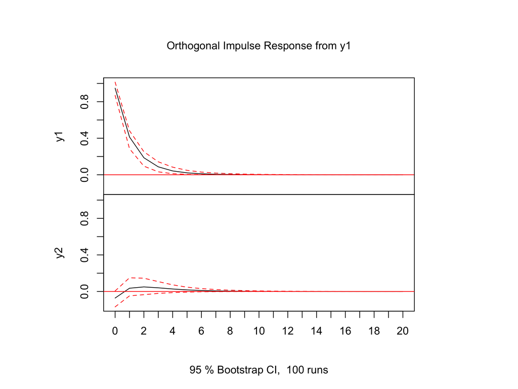

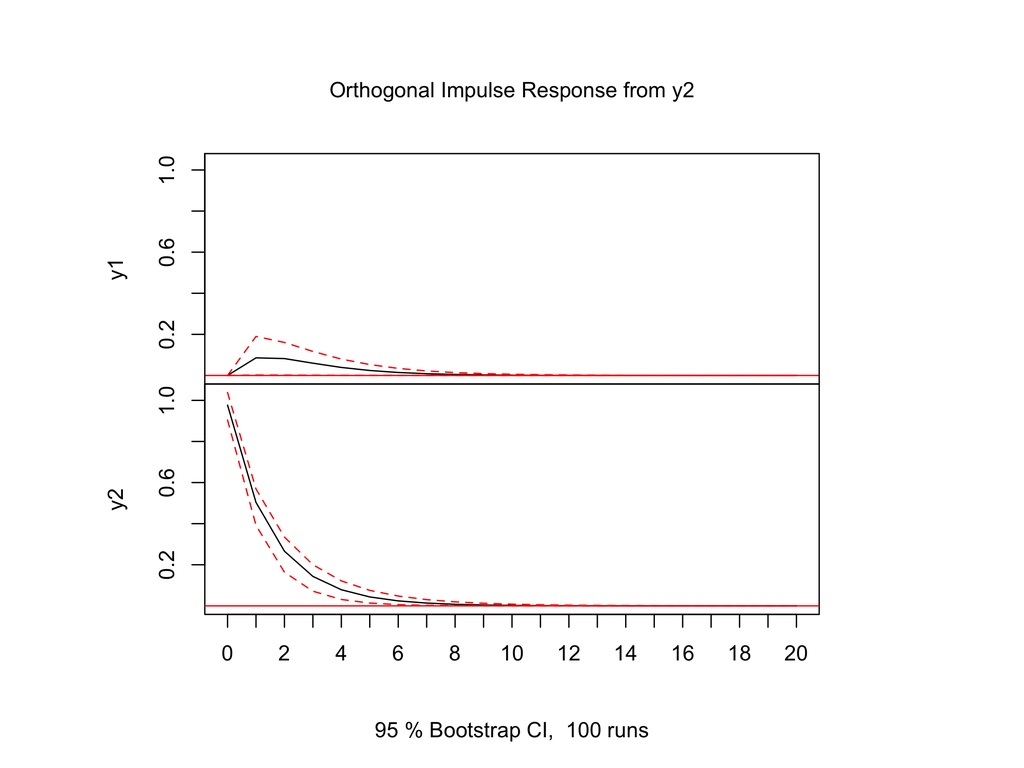

```r
irf_safe <- function(model, impulse = colnames(model$y), response = colnames(model$y),
                     n.ahead = 20, boot = TRUE, ci = 0.95) {
  out <- try(irf(model, impulse = impulse, response = response,
                 n.ahead = n.ahead, boot = boot, ci = ci, ortho = TRUE), silent = TRUE)
  if (inherits(out, "try-error")) {
    message("IRF ortogonal gagal (kovarians tidak PD). Menggunakan GIRF (ortho=FALSE).")
    out <- irf(model, impulse = impulse, response = response,
               n.ahead = n.ahead, boot = boot, ci = ci, ortho = FALSE)
  }
  out
}

irf_obj <- irf_safe(m, n.ahead = 20, boot = TRUE)
# Longgarkan margin & print
op <- par(no.readonly = TRUE); on.exit(par(op), add = TRUE)
par(mfrow=c(1,1), mar=c(4.5,4.5,2,1))
plot(irf_obj)
```

### 9.10.6 FEVD — Base Plot dan Alternatif ggplot (hindari margin error)

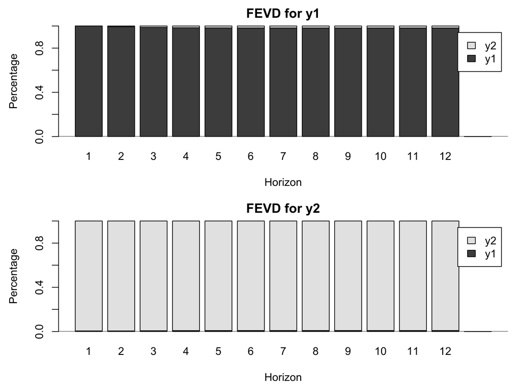

```r
fevd_obj <- fevd(m, n.ahead = 12)
op <- par(no.readonly = TRUE); on.exit(par(op), add = TRUE)
par(mfrow=c(1,1), mar=c(4.5,4.5,2,1))
plot(fevd_obj)  # barplot base dari vars
```

Alternatif **ggplot** yang robust (stacked area per horizon) — *rekomendasi jika plot base error margin*.

```r
library(dplyr)
library(tidyr)
library(purrr)
library(ggplot2)

# Pastikan fevd_obj sudah ada
if (!exists("fevd_obj")) {
  fevd_obj <- fevd(m, n.ahead = 12)
}

# Ambil list matriks FEVD
fevd_list <- fevd_obj$fevd

# Ubah jadi data.frame panjang
fevd_df <- imap_dfr(fevd_list, function(mat, resp) {
  if (is.null(dim(mat))) return(NULL)  # skip jika bukan matrix
  as.data.frame(mat) |>
    mutate(horizon = seq_len(nrow(mat)) - 1,
           response = resp)
})

# Deteksi jika tidak ada kolom numerik
if (ncol(fevd_df) <= 2) {
  warning("FEVD data tidak berisi kolom impulse. Periksa model VAR Anda.")
} else {
  id_cols    <- c("horizon", "response")
  value_cols <- setdiff(names(fevd_df), id_cols)

  fevd_long <- pivot_longer(
    fevd_df,
    cols = all_of(value_cols),
    names_to = "impulse",
    values_to = "share"
  )

  ggplot(fevd_long, aes(x = horizon, y = share, fill = impulse)) +
    geom_area(position = "stack") +
    facet_wrap(~ response, ncol = 1, scales = "free_y") +
    labs(title = "Forecast Error Variance Decomposition (FEVD)",
         x = "Horizon", y = "Share") +
    theme_minimal(base_size = 12)
}
```

[output not shown]

### 9.10.7 Contoh Data Nyata (`vars::Canada`)

```r
data("Canada", package = "vars")
sel <- VARselect(Canada, lag.max = 8, type = "const")
p_sc <- sel$selection["SC(n)"]
m_can <- VAR(Canada, p = p_sc, type = "const")
roots(m_can)
```

```
## [1] 0.9927905 0.9526365 0.9526365 0.7511478
```

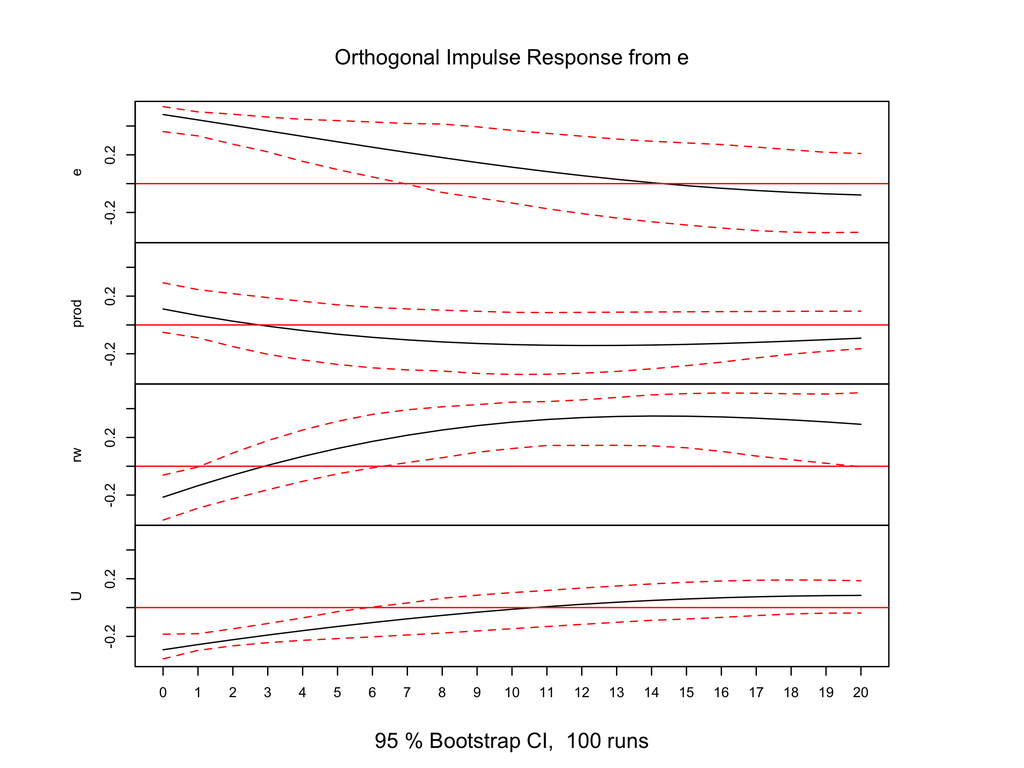

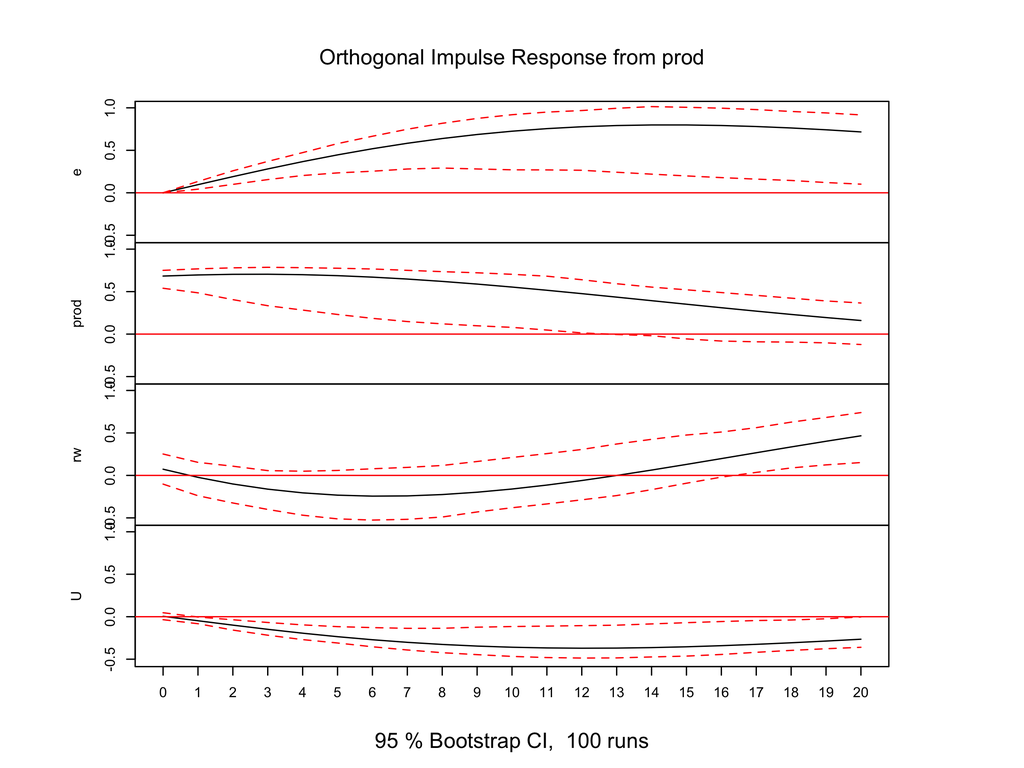

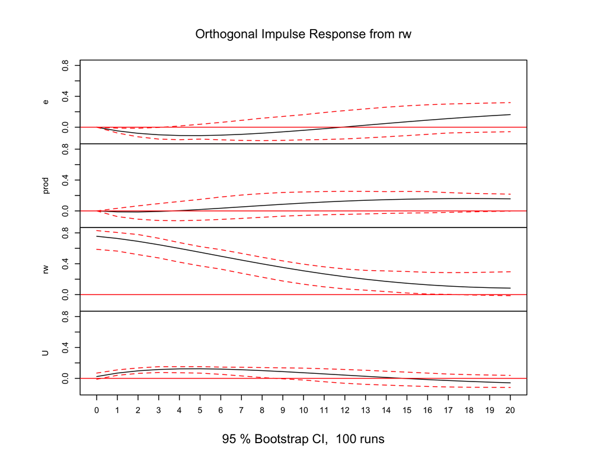

```r
irf_can <- irf_safe(m_can, n.ahead = 20, boot = TRUE)
op <- par(no.readonly = TRUE); on.exit(par(op), add = TRUE)
par(mfrow=c(1,1), mar=c(4.5,4.5,2,1))
plot(irf_can)
```

[figure not shown]

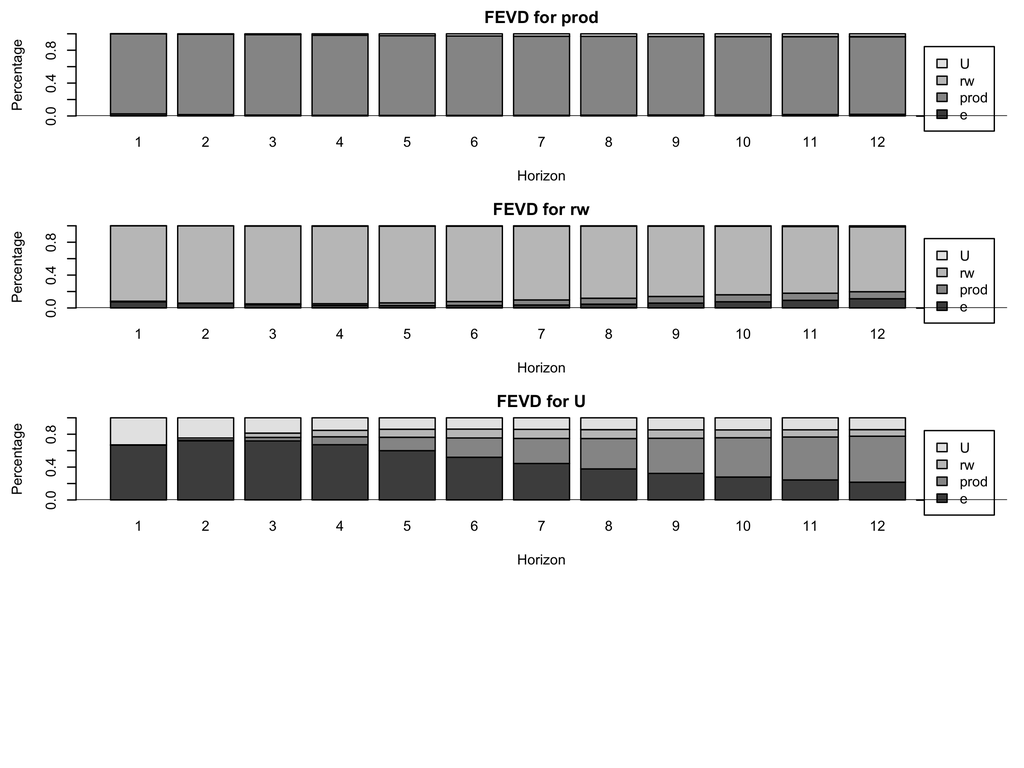

```r
fevd_can <- fevd(m_can, n.ahead = 12)
op <- par(no.readonly = TRUE); on.exit(par(op), add = TRUE)
par(mfrow=c(1,1), mar=c(4.5,4.5,2,1))
plot(fevd_can)
```

**Tips Praktis & Interpretasi**

1. **Ordering (Cholesky)**: tentukan urutan variabel berdasar teori/identifikasi; hasil IRF ortogonal berubah jika ordering berubah.
2. **GIRF**: gunakan saat $\Sigma_u$ tidak positif-definit atau ingin hasil invarian terhadap ordering.
3. **Horizon**: pilih $H$ cukup panjang (20–40) agar respon kembali ke baseline.
4. **Interval ketidakpastian**: `boot=TRUE` untuk CI bootstrap; pada sampel kecil gunakan lebih banyak replikasi.
5. **Stabilitas**: selalu cek `roots(model) < 1` sebelum IRF/FEVD.
6. **Visual FEVD**: gunakan area/stacked bar untuk menekankan komposisi kontributor varians per horizon.

**Ringkasan**

- **IRF** memetakan respons dinamis akibat shock; ortogonalization (Cholesky) membuat shock bebas tetapi **sensitif terhadap ordering**; **GIRF** adalah alternatif yang invarian terhadap ordering.
- **FEVD** menguraikan **siapa menyumbang berapa** pada varians kesalahan ramalan suatu variabel di setiap horizon.
- Kode di atas siap jalan dan **robust** untuk plotting (margin diperlebar; ada opsi **ggplot**).

## 9.11 Contoh Kasus di R (paket `vars`)

Kita gunakan data **Canada** bawaan paket `vars` (indikator makro Kanada: `e` (employment), `prod` (productivity), `rw` (real wages), `U` (unemployment)). Agar ringkas dan stasioner, kita pakai **perubahan log (growth rates)** untuk tiga seri pertama, dan diferensiasi `U`.

```r
library(vars)
library(tidyverse)
library(urca)     # unit root tests
```

### 9.11.1 Siapkan Data

```r
data("Canada", package = "vars")  # ts quarterly
# Transformasi: growth rate (diff log) untuk e, prod, rw; dan diff untuk U
can_df <- as_tibble(Canada) |>
  mutate(
    le   = log(e),
    lprod= log(prod),
    lrw  = log(rw)
  ) |>
  mutate(
    d_le    = c(NA, diff(le)),
    d_lprod = c(NA, diff(lprod)),
    d_lrw   = c(NA, diff(lrw)),
    d_U     = c(NA, diff(U))
  ) |>
  drop_na(d_le, d_lprod, d_lrw, d_U)

glimpse(can_df)
```

```
## Rows: 83
## Columns: 11
## $ e       <dbl> 929.8040, 930.3184, 931.4277, 932.6620, 933.5509, 933.5315, 93…
## $ prod    <dbl> 404.6398, 403.8149, 404.2158, 405.0467, 404.4167, 402.8191, 40…
## $ rw      <dbl> 388.1358, 390.5401, 393.9638, 396.7647, 400.0217, 400.7515, 40…
## $ U       <dbl> 7.70, 7.47, 7.27, 7.37, 7.13, 7.40, 8.33, 8.83, 10.43, 12.20, …
## $ le      <dbl> 6.834974, 6.835527, 6.836719, 6.838043, 6.838996, 6.838975, 6.…
## $ lprod   <dbl> 6.002997, 6.000957, 6.001949, 6.004002, 6.002446, 5.998488, 5.…
## $ lrw     <dbl> 5.961355, 5.967531, 5.976259, 5.983343, 5.991519, 5.993342, 6.…
## $ d_le    <dbl> 2.080985e-04, 5.530851e-04, 1.191677e-03, 1.324312e-03, 9.5266…
## $ d_lprod <dbl> -1.794141e-03, -2.040810e-03, 9.922648e-04, 2.053575e-03, -1.5…
## $ d_lrw   <dbl> 0.0051652516, 0.0061755129, 0.0087283848, 0.0070843162, 0.0081…
## $ d_U     <dbl> 0.17, -0.23, -0.20, 0.10, -0.24, 0.27, 0.93, 0.50, 1.60, 1.77,…
```

### 9.11.2 Uji Akar Unit (sekilas)

```r
adf_le    <- ur.df(can_df$d_le, type = "drift", selectlags = "AIC")
adf_lprod <- ur.df(can_df$d_lprod, type = "drift", selectlags = "AIC")
adf_lrw   <- ur.df(can_df$d_lrw, type = "drift", selectlags = "AIC")
adf_U     <- ur.df(can_df$d_U, type = "drift", selectlags = "AIC")

summary(adf_le)
```

```
##
## ###############################################
## # Augmented Dickey-Fuller Test Unit Root Test #
## ###############################################
##
## Test regression drift
##
##
## Call:
## lm(formula = z.diff ~ z.lag.1 + 1 + z.diff.lag)
##
## Residuals:
##        Min         1Q     Median         3Q        Max
## -9.716e-04 -2.668e-04 -2.083e-05  2.900e-04  7.841e-04
##
## Coefficients:
##               Estimate Std. Error t value Pr(>|t|)
## (Intercept)  1.491e-04  5.622e-05   2.651  0.00971 **
## z.lag.1     -3.595e-01  7.927e-02  -4.536 2.05e-05 ***
## z.diff.lag   3.241e-01  1.076e-01   3.011  0.00350 **
## ---
## Signif. codes:  0 '***' 0.001 '**' 0.01 '*' 0.05 '.' 0.1 ' ' 1
##
## Residual standard error: 0.0004141 on 78 degrees of freedom
## Multiple R-squared:  0.2251, Adjusted R-squared:  0.2052
## F-statistic: 11.33 on 2 and 78 DF,  p-value: 4.789e-05
##
##
## Value of test-statistic is: -4.536 10.2891
##
## Critical values for test statistics:
##       1pct  5pct 10pct
## tau2 -3.51 -2.89 -2.58
## phi1  6.70  4.71  3.86
```

> Dari praktik umum, growth/difference biasanya stasioner. Kita lanjutkan dengan VAR pada \((d\_le, d\_lprod, d\_lrw, d\_U)\).

### 9.11.3 Pilih Lag Optimum

```r
library(dplyr)
Y <- as.matrix(dplyr::select(can_df, d_le, d_lprod, d_lrw, d_U))

lag_sel <- VARselect(Y, lag.max = 8, type = "const")
lag_sel$selection  # Rekomendasi AIC/SC/HQ
```

```
## AIC(n)  HQ(n)  SC(n) FPE(n)
##      2      1      1      2
```

```r
lag_sel$criteria   # Semua nilai kriteria
```

```
##                    1             2             3             4             5
## AIC(n) -4.416680e+01 -4.419681e+01 -4.395284e+01 -4.397229e+01 -4.373554e+01
## HQ(n)  -4.392005e+01 -4.375264e+01 -4.331127e+01 -4.313330e+01 -4.269915e+01
## SC(n)  -4.354881e+01 -4.308441e+01 -4.234605e+01 -4.187110e+01 -4.113995e+01
## FPE(n)  6.590898e-20  6.420800e-20  8.273024e-20  8.260333e-20  1.077925e-19
##                    6             7             8
## AIC(n) -4.349295e+01 -4.328747e+01 -4.326637e+01
## HQ(n)  -4.225915e+01 -4.185626e+01 -4.163775e+01
## SC(n)  -4.040297e+01 -3.970309e+01 -3.918759e+01
## FPE(n)  1.436324e-19  1.880081e-19  2.097188e-19
```

### 9.11.4 Estimasi VAR

```r
p_opt <- lag_sel$selection[1]   # ambil satu (misal AIC)
var_mod <- VAR(Y, p = p_opt, type = "const")

summary(var_mod)
```

```
##
## VAR Estimation Results:
## =========================
## Endogenous variables: d_le, d_lprod, d_lrw, d_U
## Deterministic variables: const
## Sample size: 81
## Log Likelihood: 1346.623
## Roots of the characteristic polynomial:
## 0.667 0.667 0.5478 0.5478 0.4377 0.4377 0.3887 0.3448
## Call:
## VAR(y = Y, p = p_opt, type = "const")
##
##
## Estimation results for equation d_le:
## =====================================
## d_le = d_le.l1 + d_lprod.l1 + d_lrw.l1 + d_U.l1 + d_le.l2 + d_lprod.l2 + d_lrw.l2 + d_U.l2 + const
##
##              Estimate Std. Error t value Pr(>|t|)
## d_le.l1     9.357e-01  1.522e-01   6.149 3.91e-08 ***
## d_lprod.l1  7.723e-02  2.740e-02   2.818  0.00623 **
## d_lrw.l1   -1.305e-02  2.136e-02  -0.611  0.54327
## d_U.l1      9.867e-05  2.065e-04   0.478  0.63419
## d_le.l2    -3.723e-01  1.641e-01  -2.269  0.02629 *
## d_lprod.l2  9.035e-03  2.809e-02   0.322  0.74864
## d_lrw.l2   -2.026e-02  2.083e-02  -0.973  0.33393
## d_U.l2     -6.821e-05  2.156e-04  -0.316  0.75265
## const       2.260e-04  9.671e-05   2.337  0.02223 *
## ---
## Signif. codes:  0 '***' 0.001 '**' 0.01 '*' 0.05 '.' 0.1 ' ' 1
##
##
## Residual standard error: 0.0003926 on 72 degrees of freedom
## Multiple R-Squared: 0.6497,  Adjusted R-squared: 0.6108
## F-statistic: 16.69 on 8 and 72 DF,  p-value: 1.041e-13
##
##
## Estimation results for equation d_lprod:
## ========================================
## d_lprod = d_le.l1 + d_lprod.l1 + d_lrw.l1 + d_U.l1 + d_le.l2 + d_lprod.l2 + d_lrw.l2 + d_U.l2 + const
##
```

[output cut: 64 more lines]

```
##
##
## Covariance matrix of residuals:
##               d_le    d_lprod      d_lrw        d_U
## d_le     1.541e-07 -4.322e-08 -3.850e-09 -7.773e-05
## d_lprod -4.322e-08  2.569e-06  3.696e-07 -1.687e-06
## d_lrw   -3.850e-09  3.696e-07  4.237e-06  1.179e-04
## d_U     -7.773e-05 -1.687e-06  1.179e-04  8.426e-02
##
## Correlation matrix of residuals:
##              d_le   d_lprod     d_lrw       d_U
## d_le     1.000000 -0.068693 -0.004765 -0.682158
## d_lprod -0.068693  1.000000  0.112010 -0.003627
## d_lrw   -0.004765  0.112010  1.000000  0.197328
## d_U     -0.682158 -0.003627  0.197328  1.000000
```